# Notebook_Sprint-3

Olá, Marcelo

Meu nome é Ramon. Fico feliz em revisar seu projeto. Ao ao longo do texto farei algumas observações sobre melhorias no código e também farei comentários sobre suas percepções sobre o assunto. Estarei aberto a feedbacks e discussões sobre o tema.

**Peço que mantenha e não altere os comentários que eu fizer por aqui para que possamos nos localizar posteriormente, ok?**

Mais uma coisa, vamos utilizar um código de cores para você entender os meus feedbacks no seu notebook. Funciona assim:

**Comentário do revisor:**

Sucesso. Tudo foi feito corretamente.

**Comentário do revisor:**

Alerta não crítco, mas que pode ser corrigido para melhoria geral no seu código/análise

**Comentário do revisor:** Erro que precisa ser consertado, caso contrário seu projeto **não** será aceito.

Você pode me responder usando isso:

**Resposta do Aluno.**

**Comentário Geral do Revisor**

Obrigado por enviar seu projeto. Parabéns, você fez um bom trabalho.

Como pontos fortes do projeto, destaco:

- Código simples e eficiente (sem loop desnecessário)
- Uso adequado dos recursos da lição
- você programa muito bem. o projeto está impecável. Porém, há espaço para melhorias conforme os itens apontados anteriormente. Destaco os pontos a seguir: * apenas precisa plotar um gráfico.

Portanto, sugiro que você corrija os pontos indicados. Se você tiver alguma dúvida sobre de algo que você não tenha entendido, sinta-se à vontade para perguntar ao tutor ou deixar um comentário em **azul** para que, na próxima iteração, eu possa responder.

Conte conosco. Lembre-se de que você pode tirar dúvidas com revisores usando os comentários ou buscar ajuda de um tutor. Bom trabalho.

**Comentário Geral do Revisor Final:**

Tudo certo agora. Desejo sucesso na jornada. Parabéns pelo empenho.

# Introdução

O Instacart é uma plataforma de entrega de supermercado onde os clientes podem fazer um pedido no supermercado e depois receber sua compra, semelhante ao funcionamento do Uber Eats e do iFood. O conjunto de dados que fornecemos foi modificado a partir do original. Reduzimos o tamanho dele para que seus cálculos sejam executados mais rapidamente e incluímos valores ausentes e duplicados. Também tivemos o cuidado de preservar as distribuições dos dados originais quando fizemos as alterações.

Você precisa completar três etapas. Para cada uma delas, escreva uma breve introdução descrevendo como você pretende concluir a etapa e justifique suas decisões em parágrafos explicativos a medida que você avança na solução. Escreva também uma conclusão para resumir suas conclusões e escolhas.

## Dicionário de dados

Há cinco tabelas no conjunto de dados, e você vai precisar usar todas elas para pré-processar seus dados e fazer AED. Abaixo está um dicionário que lista as colunas de cada tabela e descreve os dados contidos nelas.

- `instacart_orders.csv`: cada linha corresponde a um pedido no aplicativo da Instacart
  - `'order_id'`: é o número que identifica cada pedido de forma exclusiva
  - `'user_id'`: é o número de identificação exclusivo da conta de cada cliente
  - `'order_number'`: é o número de vezes que o cliente fez um pedido
  - `'order_dow'`: é o dia da semana em que o pedido foi feito (0 é domingo)
  - `'order_hour_of_day'`: é a hora do dia em que o pedido foi feito
  - `'days_since_prior_order'`: é o número de dias desde que o cliente fez seu pedido anterior
- `products.csv`: cada linha corresponde a um produto exclusivo que os clientes podem comprar
  - `'product_id'`: é o número de identificação unívoco de cada produto
  - `'product_name'`: é o nome do produto
  - `'aisle_id'`: é o número de identificação exclusivo de cada categoria de corredor do supermercado
  - `'department_id'`: é o número de identificação exclusivo de cada categoria de departamento do supermercado
- `order_products.csv`: cada linha corresponde a um item incluído em um pedido
  - `'order_id'`: é o número que identifica cada pedido de forma exclusiva
  - `'product_id'`: é o número de identificação exclusivo de cada produto
  - `'add_to_cart_order'`: é a ordem sequencial em que cada item foi colocado no carrinho
  - `'reordered'`: 0 se o cliente nunca comprou o produto antes, 1 se já o comprou
- `aisles.csv`
  - `'aisle_id'`: é o número de identificação exclusivo de cada categoria de corredor do supermercado
  - `'aisle'`: é o nome do corredor
- `departments.csv`
  - `'department_id'`: é o número de identificação exclusivo de cada categoria de departamento do supermercado
  - `'department'`: é o nome do departamento

# Etapa 1. Visão geral dos dados

Leia os arquivos de dados (/datasets/instacart_orders.csv, /datasets/products.csv, /datasets/aisles.csv, /datasets/departments.csv e /datasets/order_products.csv) com `pd.read_csv()` usando os parâmetros apropriados para fazer isso corretamente. Verifique as informações para cada DataFrame criado.

## Plano de solução

Escreva aqui seu plano para a Etapa 1. Visão geral dos dados

O plano para essa primeira etapa é importar a bibloteca Pandas, depois imprimir as informações para cada DaFrame

```python
# Importe as bibliotecas
import pandas as pd
```

```python
# leia os conjuntos de dados em DataFrames
df_instacart_orders = pd.read_csv('instacart_orders.csv', sep=';')

df_products = pd.read_csv('products.csv', sep=';')

df_order_products = pd.read_csv('order_products.csv', sep=';')

df_aisle = pd.read_csv('aisles.csv', sep=';')

df_departments = pd.read_csv('departments.csv', sep=';')
```

```python
# imprima as informações sobre o DataFrame
print(df_instacart_orders.info())
```

```
<class 'pandas.core.frame.DataFrame'>
RangeIndex: 478967 entries, 0 to 478966
Data columns (total 6 columns):
 #   Column                  Non-Null Count   Dtype
---  ------                  --------------   -----
 0   order_id                478967 non-null  int64
 1   user_id                 478967 non-null  int64
 2   order_number            478967 non-null  int64
 3   order_dow               478967 non-null  int64
 4   order_hour_of_day       478967 non-null  int64
 5   days_since_prior_order  450148 non-null  float64
dtypes: float64(1), int64(5)
memory usage: 21.9 MB
None
```

```python
# imprima as informações sobre o DataFrame
print(df_products.info())
```

```
<class 'pandas.core.frame.DataFrame'>
RangeIndex: 49694 entries, 0 to 49693
Data columns (total 4 columns):
 #   Column         Non-Null Count  Dtype
---  ------         --------------  -----
 0   product_id     49694 non-null  int64
 1   product_name   48436 non-null  object
 2   aisle_id       49694 non-null  int64
 3   department_id  49694 non-null  int64
dtypes: int64(3), object(1)
memory usage: 1.5+ MB
None
```

```python
# imprima as informações sobre o DataFrame
print(df_order_products.info(show_counts=True))
```

```
<class 'pandas.core.frame.DataFrame'>
RangeIndex: 4545007 entries, 0 to 4545006
Data columns (total 4 columns):
 #   Column             Non-Null Count    Dtype
---  ------             --------------    -----
 0   order_id           4545007 non-null  int64
 1   product_id         4545007 non-null  int64
 2   add_to_cart_order  4544171 non-null  float64
 3   reordered          4545007 non-null  int64
dtypes: float64(1), int64(3)
memory usage: 138.7 MB
None
```

```python
# imprima as informações sobre o DataFrame
print(df_aisle.info())
```

```
<class 'pandas.core.frame.DataFrame'>
RangeIndex: 134 entries, 0 to 133
Data columns (total 2 columns):
 #   Column    Non-Null Count  Dtype
---  ------    --------------  -----
 0   aisle_id  134 non-null    int64
 1   aisle     134 non-null    object
dtypes: int64(1), object(1)
memory usage: 2.2+ KB
None
```

```python
# imprima as informações sobre o DataFrame
print(df_departments.info())
```

```
<class 'pandas.core.frame.DataFrame'>
RangeIndex: 21 entries, 0 to 20
Data columns (total 2 columns):
 #   Column         Non-Null Count  Dtype
---  ------         --------------  -----
 0   department_id  21 non-null     int64
 1   department     21 non-null     object
dtypes: int64(1), object(1)
memory usage: 468.0+ bytes
None
```

## Conclusões

Escreva aqui suas conclusões intermediárias da Etapa 1. Visão geral dos dados

- Primeiro utilizei o método .head() para ver como os dados estavam apresentados na tabela. Percebi que o separador utilizado era ';', então utilizei o parametro sep=';' para organizar os dados e chamei o metodo info() em seguida
- Para o df_order_products, como descrito no enunciado, a contagem dos valores nao foi exibida somente com o método info(), depois de incluir show_counts tudo ficou como eu queria.

# Etapa 2. Preparação de dados

Faça o pré-processamento dos dados da seguinte maneira:

- Verifique e corrija os tipos de dados (por exemplo, certifique-se de que as colunas de ID sejam números inteiros)
- Identifique e preencha valores ausentes
- Identifique e remova valores duplicados

Certifique-se de explicar que tipos de valores ausentes e duplicados você encontrou, como você os preencheu ou removeu, por que escolheu esses métodos e por que você acha que esses valores ausentes e duplicados estavam presentes no conjunto de dados.

## Encontre e remova valores duplicados (e descreva por que você está fazendo suas escolhas)

### DataFrame `instacart_orders`

```python
# Verificar se há pedidos duplicados
print(df_instacart_orders[df_instacart_orders.duplicated()])
```

```
        order_id  user_id  order_number  order_dow  order_hour_of_day  \
145574    794638    50898            24          3                  2
223105   2160484   107525            16          3                  2
230807   1918001   188546            14          3                  2
266232   1782114   106752             1          3                  2
273805   1112182   202304            84          3                  2
284038   2845099    31189            11          3                  2
311713   1021560    53767             3          3                  2
321100    408114    68324             4          3                  2
323900   1919531   191501            32          3                  2
345917   2232988    82565             1          3                  2
371905    391768    57671            19          3                  2
394347    467134    63189            21          3                  2
411408   1286742   183220            48          3                  2
415163   2282673    86751            49          3                  2
```

[output cut: 18 more lines]

```python
df_instacart_orders.head()
```

|  | order_id | user_id | order_number | order_dow | order_hour_of_day | days_since_prior_order |
| --- | --- | --- | --- | --- | --- | --- |
| 0 | 1515936 | 183418 | 11 | 6 | 13 | 30.0 |
| 1 | 1690866 | 163593 | 5 | 5 | 12 | 9.0 |
| 2 | 1454967 | 39980 | 4 | 5 | 19 | 2.0 |
| 3 | 1768857 | 82516 | 56 | 0 | 20 | 10.0 |
| 4 | 3007858 | 196724 | 2 | 4 | 12 | 17.0 |

Há linhas duplicadas? Se sim, o que elas têm em comum?

- Todos os pedidos duplicados foram feitos na quarta-feira as 2 da manhã

```python
# Com base nas suas conclusões,
# verifique todos os pedidos feitos às 2h da manhã nas quartas-feiras
print(df_instacart_orders[(df_instacart_orders['order_dow'] == 3)&(df_instacart_orders['order_hour_of_day'] ==2)])
```

```
        order_id  user_id  order_number  order_dow  order_hour_of_day  \
4838     2766110   162084            41          3                  2
5156     2190225   138285            18          3                  2
15506     553049    58599            13          3                  2
18420     382357   120200            19          3                  2
24691     690242    77357             2          3                  2
...          ...      ...           ...        ...                ...
457013   3384021    14881             6          3                  2
458816    910166   164782            18          3                  2
459635   1680532   106435             6          3                  2
468324    222962    54979            59          3                  2
477526   2592344    46860            38          3                  2

        days_since_prior_order
4838                      16.0
5156                      11.0
15506                      7.0
18420                     11.0
24691                      9.0
...                        ...
457013                    30.0
458816                     4.0
459635                    21.0
468324                     3.0
477526                     3.0

[121 rows x 6 columns]
```

O que esse resultado quer dizer?

O resultado nos mostra que nem todas as compras realizadas neste dia e hora específicos são duplicados

```python
# Remova pedidos duplicados
df_instacart_orders = df_instacart_orders.drop_duplicates()
```

```python
# Verifique as linhas duplicadas mais uma vez
print(df_instacart_orders.duplicated().sum())
```

```
0
```

```python
# Verifique novamente apenas os IDs de pedidos duplicados
print(df_instacart_orders['order_id'].duplicated().sum())
```

```
0
```

Descreva brevemente suas conclusões e o que você fez com elas.

- Concluimos que os dados relevantes duplicados nessa coluna são apenas os da coluna 'order_id', já que ela deve conter um número de identificação EXCLUSIVO de cada pedido.
- Depois de identificados eles foram devidamente exluídos e depois verificados novamente para confirmar que não existem mais pedidos duplicados.

### DataFrame `products`

```python
# Verifique se há linhas completamente duplic_das
print(df_products.duplicated().sum())
```

```
0
```

```python
# Verifique apenas IDs dos produtos duplicados
print(df_products['product_id'].duplicated().sum())
```

```
0
```

```python
# Verifique apenas nomes de produtos duplicados (converta os nomes para minúsculas para uma comparação melhor)
df_products['product_name'] = df_products['product_name'].str.lower()
df_products[df_products['product_name'].duplicated(keep=False)]
```

|  | product_id | product_name | aisle_id | department_id |
| --- | --- | --- | --- | --- |
| 37 | 38 | NaN | 100 | 21 |
| 41 | 42 | biotin 1000 mcg | 47 | 11 |
| 71 | 72 | NaN | 100 | 21 |
| 109 | 110 | NaN | 100 | 21 |
| 185 | 186 | fresh scent dishwasher detergent with dawn | 74 | 17 |
| ... | ... | ... | ... | ... |
| 49689 | 49690 | high performance energy drink | 64 | 7 |
| 49690 | 49691 | original pancake & waffle mix | 130 | 14 |
| 49691 | 49692 | organic instant oatmeal light maple brown sugar | 130 | 14 |
| 49692 | 49693 | spring water body wash | 127 | 11 |
| 49693 | 49694 | burrito- steak & cheese | 38 | 1 |

1465 rows × 4 columns

```python
# Verifique os nomes de produtos duplicados que não estão faltando
import numpy as np
df_products['product_name'] = df_products['product_name'].replace('unknown', np.nan)
df_products[df_products['product_name'].duplicated() & df_products['product_name'].notna()]
```

|  | product_id | product_name | aisle_id | department_id |
| --- | --- | --- | --- | --- |
| 2058 | 2059 | biotin 1000 mcg | 47 | 11 |
| 5455 | 5456 | green tea with ginseng and honey | 96 | 20 |
| 5558 | 5559 | cream of mushroom soup | 69 | 15 |
| 7558 | 7559 | cinnamon rolls with icing | 105 | 13 |
| 9037 | 9038 | american cheese slices | 21 | 16 |
| ... | ... | ... | ... | ... |
| 49689 | 49690 | high performance energy drink | 64 | 7 |
| 49690 | 49691 | original pancake & waffle mix | 130 | 14 |
| 49691 | 49692 | organic instant oatmeal light maple brown sugar | 130 | 14 |
| 49692 | 49693 | spring water body wash | 127 | 11 |
| 49693 | 49694 | burrito- steak & cheese | 38 | 1 |

104 rows × 4 columns

Descreva brevemente suas conclusões e o que você fez com elas.

Foram identificados nomes de produtos duplicados, mas os outros campos não são equivalentes. Todos os nomes ausentes foram substiruídos por 'unknown'.

### DataFrame `departments`

```python
# Verifique se há linhas completamente duplicadas
print(df_departments.duplicated().sum())
```

```
0
```

```python
# Verifique apenas se há IDs dos produtos duplicados
print(df_departments['department_id'].duplicated().sum())
```

```
0
```

Descreva brevemente suas conclusões e o que você fez com elas.

Não existem números de identificação ou nomes de departamentos duplicadas nesse DF

### DataFrame `aisles`

```python
# Verifique se há linhas completamente duplicadas
print(df_aisle.duplicated().sum())
```

```
0
```

```python
# Verifique apenas se há IDs dos produtos duplicados
print(df_aisle['aisle_id'].duplicated().sum())
```

```
0
```

Descreva brevemente suas conclusões e o que você fez com elas.

Não existem identificadores ou nomes de categorias duplicados

### DataFrame `order_products`

```python
# Verifique se há linhas completamente duplicadas
print(df_order_products.duplicated().all().sum())
```

```
0
```

```python
# Verifique mais uma vez se há outros casos complicados de duplicados
print(df_order_products['order_id'].duplicated().sum())
```

```
4094961
```

Descreva brevemente suas conclusões e o que você fez com elas.

Existe uma quantidade considerável de valores duplicados na coluna 'order_id', porém como cada linha corresponde a um ítem incluído em um pedido, um pedido com múltiplos ítens gera várias linhas com o mesmo 'order_id'. Nenhuma ação é necessária.

## Encontre e remova valores ausentes

Ao processarmos valores duplicados, observamos que também temos valores ausentes que precisamos investigar nas seguintes colunas:

- A coluna `'product_name'` da tabela products.
- A coluna `'days_since_prior_order'` da tabela orders.
- A coluna `'add_to_cart_order'` da tabela order_products.

### DataFrame `products`

```python
# Encontre valores ausentes na coluna 'product_name'
missing_product_name = df_products['product_name'].value_counts(dropna=False)
print(missing_product_name.head(5))
```

```
product_name
NaN                                            1258
green tea with ginseng and honey                  3
hearts of palm                                    2
diced peeled tomatoes in tomato juice             2
flat fillets of anchovies in pure olive oil       2
Name: count, dtype: int64
```

Descreva brevemente suas conclusões.

Temos 1258 valores ausentes na coluna 'product_name', o que equivale a aproximadamente 2,52% do total de produtos

```python
# Todos os nomes de produtos ausentes estão associados com o corredor de ID 100?
print(df_products[(df_products['product_name'].isna()) & (df_products['aisle_id'] != 100)])
```

```
Empty DataFrame
Columns: [product_id, product_name, aisle_id, department_id]
Index: []
```

Descreva brevemente suas conclusões.

Sim, todos os nomes de produtos ausentes estão associados com o corredor de ID 100

```python
# Todos os nomes de produtos ausentes estão associados com o departamento de ID 21?
print(df_products[(df_products['product_name'].isna()) & (df_products['department_id'] != 21)])
```

```
Empty DataFrame
Columns: [product_id, product_name, aisle_id, department_id]
Index: []
```

Descreva brevemente suas conclusões.

Sim, todos os nomes de produtos ausentes estão associados ao departamento de ID 21

```python
# Use as tabelas department e aisle para verificar os dados do corredor com ID 100 e do departamento com ID 21.
print(df_aisle[df_aisle['aisle_id']==100])
print()
print(df_departments[df_departments['department_id']==21])
```

```
    aisle_id    aisle
99       100  missing

    department_id department
20             21    missing
```

Descreva brevemente suas conclusões.

Os nomes, tanto do corredor com ID 100 e do departamento com ID 21, estão faltando.

```python
# Preencha nomes de produtos ausentes com 'Unknown'
df_products['product_name'] = df_products['product_name'].fillna('Unknown')
print(df_products['product_name'].value_counts())
```

```
product_name
Unknown                                        1258
green tea with ginseng and honey                  3
hearts of palm                                    2
diced peeled tomatoes in tomato juice             2
flat fillets of anchovies in pure olive oil       2
                                               ...
vodka- triple distilled- twist of vanilla         1
en croute roast hazelnut cranberry                1
artisan baguette                                  1
smartblend healthy metabolism dry cat food        1
cut russet potatoes steam n' mash                 1
Name: count, Length: 48333, dtype: int64
```

Descreva brevemente suas conclusões e o que você fez com elas.

Todos os nomes de produtos ausentes foram substituídos por 'Unknown', e isso foi verificado com o método value_counts()

### DataFrame `orders`

```python
# Encontre os valores ausentes
print(df_instacart_orders.isna().sum())
```

```
order_id                      0
user_id                       0
order_number                  0
order_dow                     0
order_hour_of_day             0
days_since_prior_order    28817
dtype: int64
```

```python
# Há valores ausentes para os clientes que não estão fazendo o primeiro pedido?
print(df_instacart_orders[(df_instacart_orders['days_since_prior_order'].isna()) & (df_instacart_orders['order_number']>=2)])
```

```
Empty DataFrame
Columns: [order_id, user_id, order_number, order_dow, order_hour_of_day, days_since_prior_order]
Index: []
```

Descreva brevemente suas conclusões e o que você fez com elas.

Todos os valores ausentes nessa tabela estão na coluna 'days_since_prior_order' Entretanto para clientes que estão efetuando a primeira compra esse campo não se aplica. Então, verifiquei que não existem valores ausentes para os clientes que NÃO estão fazendo a primeira compra.

### DataFrame `order_products`

```python
# Encontre os valores ausentes
print(df_order_products.isna().sum())
```

```
order_id               0
product_id             0
add_to_cart_order    836
reordered              0
dtype: int64
```

```python
# Quais são os valores mínimo e máximo dessa coluna?
print(df_order_products['add_to_cart_order'].min())
print()
print(df_order_products['add_to_cart_order'].max())
```

```
1.0

64.0
```

Descreva brevemente suas conclusões.

Encontramos 836 valores ausentes na coluna 'add_to_cart_order'. O valor mínimo é 1, e o máximo 64. Logo algum problema deve estar ocorrendo quando o cliente seleciona mais de 64 produtos.

```python
# Salve todos os IDs dos pedidos com pelo menos um valor ausente em 'add_to_cart_order'
empty_orders = df_order_products[['order_id', 'add_to_cart_order']][df_order_products['add_to_cart_order'].isnull()]
empty_orders = empty_orders['order_id'].unique()
print(empty_orders)
```

```
[2449164 1968313 2926893 1717990 1959075  844733   61355  936852  264710
 1564093  129627  293169 2849370 1386261 3308010  903110 2136777 3347453
 1888628  165801 2094761 1038146 2997021  813364 2256933  171934 2409109
 1730767 1169835  733526  404157 3125735  747668 1800005 1961723  871281
  388234 1648217 1477139  102236 1021563 1832957 2721963  678116 1220886
 1673227 2999801 1633337 2470674 2625444 1677118 2479011 3383594 1183255
 1713430 2652650 1598369 1916118  854647 1302315  888470  180546 2621907
 1308785 2729254    9310 2170451 2979697 1625713 1529171]
```

```python
# Todos os pedidos com valores ausentes contêm mais de 64 produtos?
# Agrupe os pedidos com dados ausentes por ID de pedido
# Conte o número de 'product_id' em cada pedido e verifique o valor mínimo da contagem

df_missing_orders = df_order_products[df_order_products['order_id'].isin(empty_orders)]
df_missing_orders.groupby('order_id')['product_id'].count().min()
```

```
65
```

Descreva brevemente suas conclusões.

A conclusão foi de que em um pedido com mais de 64 produtos, o campo que armazena a ordem em que os produtos foram colocados no carrinho para de contar a partir do produto 65, gerando valores nulos nesse campo.

```python
# Substitua valores ausentes na coluna 'add_to_cart_order' por 999 e converta a coluna para o tipo integer
df_order_products['add_to_cart_order'] = pd.to_numeric(df_order_products['add_to_cart_order'], errors='coerce')
df_order_products['add_to_cart_order'] = df_order_products['add_to_cart_order'].fillna(999)
print(df_order_products[df_order_products['add_to_cart_order'] > 64])
```

```
         order_id  product_id  add_to_cart_order  reordered
737       2449164        5068              999.0          0
9926      1968313       43867              999.0          0
14394     2926893       11688              999.0          0
16418     1717990        4142              999.0          0
30114     1959075       42828              999.0          1
...           ...         ...                ...        ...
4505662   1800005        7411              999.0          0
4511400   1633337         260              999.0          0
4517562    404157        9517              999.0          0
4534112   1673227       17835              999.0          0
4535739   1832957       17949              999.0          1

[836 rows x 4 columns]
```

Descreva brevemente suas conclusões e o que você fez com elas.

Nos pedidos com mais de 64 produtos no carrinho, o valor ausente foi substituído por um valor numérico.

## Conclusões

Escreva aqui suas conclusões intermediárias da Etapa 2. Preparação de dados

Nem todos os dados estão em conformidades com o padrão desejado. É importante entender a estrutura das colunas, quais os tipos de dados, números de valores ausentes em cada tabela. Por que eles estão ausentes e como devemos subistitui-los. Valores duplicados também devem ser analisados e corrigidos. Somente com os dados processados e formatados é possível analisá-los.

# Etapa 3. Análise de dados

Quando os dados estiverem processados e prontos, execute a seguinte análise:

# [A] Fácil (é necessário concluir tudo para passar)

1. Verifique se os valores nas colunas `'order_hour_of_day'` e `'order_dow'` na tabela `orders` fazem sentido (ou seja, os valores da coluna `'order_hour_of_day'` variam de 0 a 23 e os da `'order_dow'` variam de 0 a 6).
2. Crie um gráfico que mostre quantas pessoas fazem pedidos a cada hora do dia.
3. Crie um gráfico que mostre em que dia da semana as pessoas fazem compras.
4. Crie um gráfico que mostre quanto tempo as pessoas esperam até fazer seu próximo pedido e comente sobre os valores mínimo e máximo.

### [A1] Verifique se os valores fazem sentido

```python
df_instacart_orders.head()
```

|  | order_id | user_id | order_number | order_dow | order_hour_of_day | days_since_prior_order |
| --- | --- | --- | --- | --- | --- | --- |
| 0 | 1515936 | 183418 | 11 | 6 | 13 | 30.0 |
| 1 | 1690866 | 163593 | 5 | 5 | 12 | 9.0 |
| 2 | 1454967 | 39980 | 4 | 5 | 19 | 2.0 |
| 3 | 1768857 | 82516 | 56 | 0 | 20 | 10.0 |
| 4 | 3007858 | 196724 | 2 | 4 | 12 | 17.0 |

```python
hour_min = df_instacart_orders['order_hour_of_day'].min()
hour_max = df_instacart_orders['order_hour_of_day'].max()
day_min = df_instacart_orders['order_dow'].min()
day_max = df_instacart_orders['order_dow'].max()
print(f'As horas do pedido variam entre: {hour_min} e {hour_max}')
print(f'Os dias do pedido variam entre: {day_min} e {day_max}')
```

```
As horas do pedido variam entre: 0 e 23
Os dias do pedido variam entre: 0 e 6
```

Escreva suas conclusões aqui

Tudo certo com os horarios e dias da semana em que os clientes fazem pedidos.

### [A2] Quantas pessoas fazem pedidos a cada hora do dia?

```python
df_pedidos_por_hora = df_instacart_orders.groupby('order_hour_of_day')['user_id'].nunique()
df_pedidos_por_hora.head()
```

```
order_hour_of_day
0    2991
1    1671
2     958
3     744
4     735
Name: user_id, dtype: int64
```

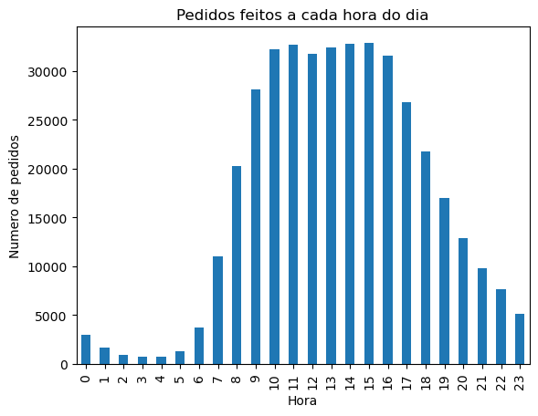

```python
from matplotlib import pyplot as plt
df_pedidos_por_hora.plot(kind='bar',
                         title='Pedidos feitos a cada hora do dia',
                         x='order_hour_of_day'
                         )

plt.xlabel('Hora')
plt.ylabel('Numero de pedidos')
plt.show()
```

Escreva suas conclusões aqui

A maioria dos pedidos são feitos entre 10 e 16h

### [A3] Em que dia da semana as pessoas compram produtos alimentícios?

```python
print(df_departments)
```

```
    department_id       department
0               1           frozen
1               2            other
2               3           bakery
3               4          produce
4               5          alcohol
5               6    international
6               7        beverages
7               8             pets
8               9  dry goods pasta
9              10             bulk
10             11    personal care
11             12     meat seafood
12             13           pantry
13             14        breakfast
14             15     canned goods
15             16       dairy eggs
16             17        household
17             18           babies
18             19           snacks
19             20             deli
20             21          missing
```

```
   Quantidade de Compras   count
0                      0  819185
1                      1  748735
2                      2  554275
3                      3  500260
4                      4  498737
5                      5  551739
6                      6  592230
```

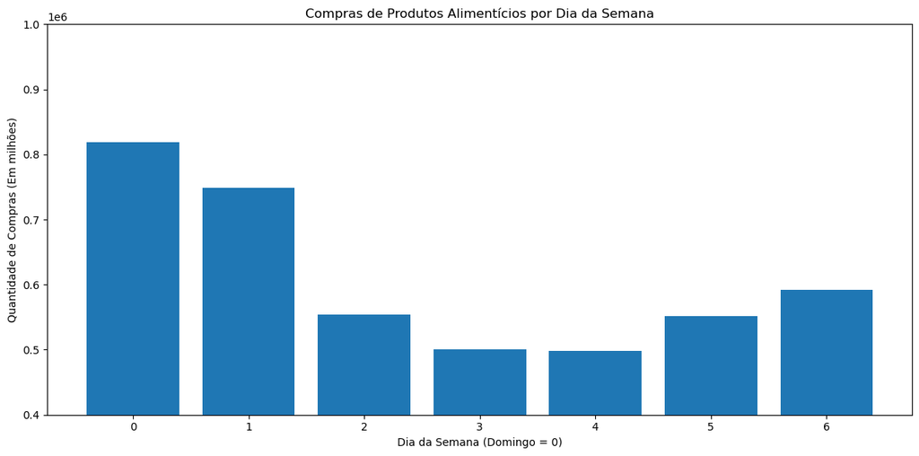

```python
departamentos_alimenticios = [1, 3, 4, 6, 7, 9, 12, 13, 14, 15, 16, 19, 20]

produtos_alimenticios = df_products[df_products['department_id'].isin(departamentos_alimenticios)]

dados = df_order_products.merge(produtos_alimenticios, on='product_id').merge(df_instacart_orders[['order_id', 'order_dow']], on='order_id')

compras_por_dia = dados['order_dow'].value_counts().sort_index()

print(compras_por_dia.reset_index().rename(columns={'index': 'Dia da Semana', 'order_dow': 'Quantidade de Compras'}))

plt.figure(figsize=(12, 6))
plt.bar(compras_por_dia.index, compras_por_dia.values)
plt.title('Compras de Produtos Alimentícios por Dia da Semana')
plt.xlabel('Dia da Semana (Domingo = 0)')
plt.ylabel('Quantidade de Compras (Em milhões)')
plt.ylim(400_000, 1_000_000)
plt.tight_layout()
plt.show()
```

Escreva suas conclusões aqui

Domingo e segunda são os dias com maior procuras no departamento de alimentos

### [A4] Quanto tempo as pessoas esperam até fazer outro pedido?

```
days_since_prior_order
0.0      9589
1.0     20179
2.0     27138
3.0     30224
4.0     31006
5.0     30096
6.0     33930
7.0     44577
8.0     25361
9.0     16753
10.0    13309
11.0    11467
12.0    10658
13.0    11737
14.0    13992
15.0     9416
16.0     6587
17.0     5498
18.0     4971
19.0     4939
20.0     5302
21.0     6448
22.0     4514
23.0     3337
24.0     3015
25.0     2711
26.0     2640
27.0     2986
28.0     3745
29.0     2673
30.0    51337
Name: count, dtype: int64
```

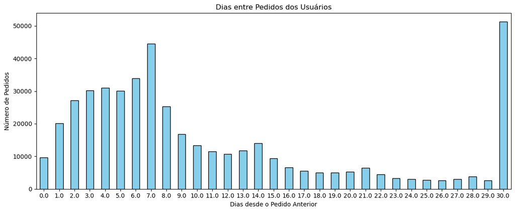

```
Mínimo: 0 dia(s)
Máximo: 30 dias
Média: 11.10 dias
```

```python
tempo_medio = df_instacart_orders['days_since_prior_order'].value_counts().sort_index()
print(tempo_medio)
tempo_medio.plot(kind='bar',
                 figsize=(12, 5),
                 color='skyblue',
                 edgecolor='black')

plt.title('Dias entre Pedidos dos Usuários')
plt.xlabel('Dias desde o Pedido Anterior')
plt.ylabel('Número de Pedidos')
plt.xticks(rotation=0)
plt.tight_layout()
plt.show()

minimo = int(tempo_medio.index.min())
maximo = int(tempo_medio.index.max())
media = df_instacart_orders['days_since_prior_order'].mean()

print(f"Mínimo: {minimo} dia(s)")
print(f"Máximo: {maximo} dias")
print(f"Média: {media:.2f} dias")
```

# [B] Médio (é necessário concluir tudo para passar)

1. Há alguma diferença nas distribuições de `'order_hour_of_day'` nas quartas e sábados? Construa gráficos de barras para ambos os dias no mesmo gráfico e descreva as diferenças que você notou.
2. Construa um gráfico de distribuição para o número de pedidos que os clientes fazem (ou seja, quantos clientes fizeram apenas 1 pedido, quantos fizeram apenas 2, quantos apenas 3, etc.)
3. Quais são os 20 produtos comprados com mais frequência? Exiba os IDs e nomes.

### [B1] Diferenças nas quartas e sábados em `'order_hour_of_day'`. Crie gráficos de barras para ambos os dias e descreva as diferenças.

```
order_hour_of_day
0      373
1      215
2      106
3      101
4      108
5      170
6      643
7     1732
8     3125
9     4490
10    5026
11    5004
12    4688
13    4674
```

[output cut: 37 more lines]

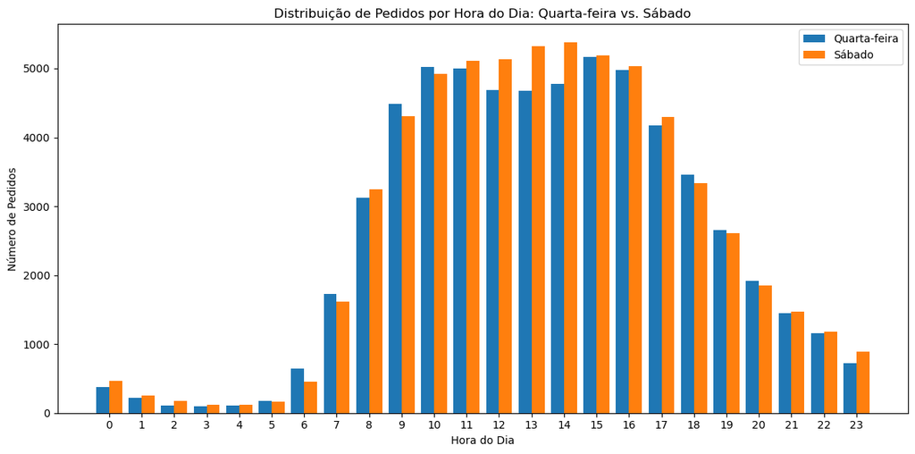

```python
quartas = df_instacart_orders[df_instacart_orders['order_dow'] == 3]
sábados = df_instacart_orders[df_instacart_orders['order_dow'] == 6]


horas_quarta = quartas['order_hour_of_day'].value_counts().sort_index()
horas_sabado = sábados['order_hour_of_day'].value_counts().sort_index()
print(horas_quarta)
print(horas_sabado)

plt.figure(figsize=(12, 6))
plt.bar(horas_quarta.index - 0.2, horas_quarta.values, width=0.4, label='Quarta-feira')
plt.bar(horas_sabado.index + 0.2, horas_sabado.values, width=0.4, label='Sábado')
plt.title('Distribuição de Pedidos por Hora do Dia: Quarta-feira vs. Sábado')
plt.xlabel('Hora do Dia')
plt.ylabel('Número de Pedidos')
plt.xticks(sorted(set(horas_quarta.index).union(horas_sabado.index)))
plt.legend()
plt.tight_layout()
plt.show()
```

### [B2] Qual é a distribuição do número de pedidos por cliente?

```python
pedidos_por_cliente = df_instacart_orders['user_id'].value_counts()
```

```python
print(pedidos_por_cliente)
```

```
user_id
149605    28
193164    26
78375     25
134511    24
148162    24
          ..
73221      1
112002     1
82546      1
60017      1
133649     1
Name: count, Length: 157437, dtype: int64
```

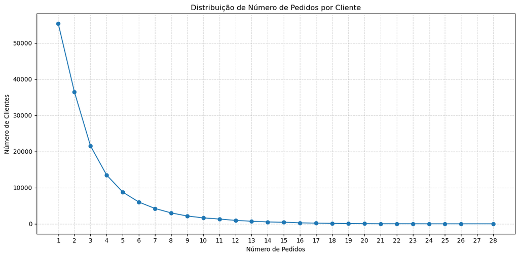

```python
distribuicao = pedidos_por_cliente.value_counts().sort_index()
plt.figure(figsize=(12, 6))
plt.plot(distribuicao.index, distribuicao.values, marker='o', linestyle='-')

plt.title('Distribuição de Número de Pedidos por Cliente')
plt.xlabel('Número de Pedidos')
plt.ylabel('Número de Clientes')
plt.xticks(range(1, distribuicao.index.max() + 1))
plt.grid(True, linestyle='--', alpha=0.5)
plt.tight_layout()
plt.show()
```

### [B3] Quais são os 20 produtos mais populares? Exiba os IDs e nomes.

```python
frequencia_produtos = df_order_products['product_id'].value_counts().reset_index()
frequencia_produtos.columns = ['product_id', 'quantidade_comprada']

top_20 = frequencia_produtos.merge(df_products[['product_id', 'product_name']], on='product_id')

top_20 = top_20.head(20)
print(top_20[['product_id', 'product_name', 'quantidade_comprada']])
```

```
    product_id              product_name  quantidade_comprada
0        24852                    banana                66050
1        13176    bag of organic bananas                53297
2        21137      organic strawberries                37039
3        21903      organic baby spinach                33971
4        47209      organic hass avocado                29773
5        47766           organic avocado                24689
6        47626               large lemon                21495
7        16797              strawberries                20018
8        26209                     limes                19690
9        27845        organic whole milk                19600
10       27966       organic raspberries                19197
11       22935      organic yellow onion                15898
12       24964            organic garlic                15292
13       45007          organic zucchini                14584
14       39275       organic blueberries                13879
15       49683            cucumber kirby                13675
16       28204        organic fuji apple                12544
17        5876             organic lemon                12232
18        8277  apple honeycrisp organic                11993
19       40706    organic grape tomatoes                11781
```

Escreva suas conclusões aqui

Os 20 produtos mais vendidos são do departamento de alimentos Entre os 20 produtos mais vendidos, 15 são orgânicos, indicando uma preocupação extra com uma alimentação saudável.

# [C] Difícil (é necessário concluir pelo menos duas perguntas para passar)

1. Quantos itens as pessoas normalmente compram em um pedido? Como fica a distribuição?
2. Quais são os 20 principais itens incluídos mais frequentemente em pedidos repetidos? Exiba os IDs e nomes.
3. Para cada produto, qual parcela de seus pedidos são repetidos? Crie uma tabela com colunas de ID e nome do produto e a proporção de pedidos repetidos.
4. Para cada cliente, qual proporção de todos os seus pedidos são repetidos?
5. Quais são os 20 principais itens que as pessoas colocam nos carrinhos antes de todos os outros? Exiba o ID do produto, nome e o número de vezes que ele foi o primeiro a ser adicionado a um carrinho.

### [C1] Quantos itens as pessoas normalmente compram em um pedido? Como fica a distribuição?

```python
itens_por_pedido = df_order_products['order_id'].value_counts()
```

```python
distribuicao = itens_por_pedido.value_counts().sort_index()
```

```python
# Em vez de reset_index() puro, vamos transformar em DataFrame e renomear
tabela = distribuicao.to_frame()
tabela.columns = ['Número de Pedidos com Essa Quantidade']
tabela.index.name = 'Número de Itens no Pedido'

# Agora resetamos o índice sem conflito
tabela = tabela.reset_index()

print(tabela.head(60))
print()
media_itens = itens_por_pedido.mean()
print(f"\nMédia de itens por pedido: {media_itens:.2f}")
```

```
    Número de Itens no Pedido  Número de Pedidos com Essa Quantidade
0                           1                                  21847
1                           2                                  26292
2                           3                                  29046
3                           4                                  31054
4                           5                                  31923
5                           6                                  31698
6                           7                                  30822
7                           8                                  28539
8                           9                                  25742
9                          10                                  23248
10                         11                                  20406
11                         12                                  18539
12                         13                                  16497
13                         14                                  14472
```

[output cut: 49 more lines]

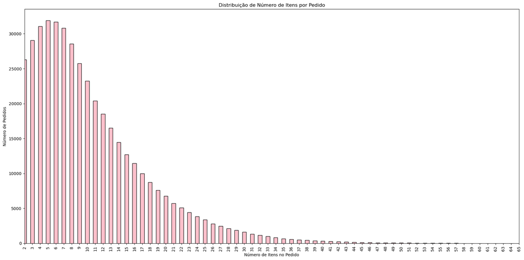

```python
plt.figure(figsize=(18, 9))
tabela.set_index('Número de Itens no Pedido')['Número de Pedidos com Essa Quantidade'] \
    .plot(kind='bar', color='pink', edgecolor='black')

plt.title('Distribuição de Número de Itens por Pedido')
plt.xlabel('Número de Itens no Pedido')
plt.ylabel('Número de Pedidos')
plt.xticks(rotation=90)
plt.xlim(1, 64)
plt.tight_layout()
plt.show()
```

Escreva suas conclusões aqui

Em média as pessoas compram 10 ítens por pedidos. Compras com 4, 5, 6, ou 7 ítens foram os únicos que superaram 30 mil vendas cada. Carrinhos com 34 ou mais produtos não alcançaram a marca de 1000 vendas

### [C2] Quais são os 20 principais itens incluídos com mais frequência em pedidos repetidos? Exiba os IDs e nomes.

```python
repetidos = df_order_products[df_order_products['reordered'] == 1]

frequencia_repetidos = repetidos['product_id'].value_counts().reset_index()
frequencia_repetidos.columns = ['product_id', 'quantidade_repetida']

top_20_repetidos = frequencia_repetidos.merge(df_products[['product_id', 'product_name']], on='product_id')

top_20_repetidos = top_20_repetidos.head(20)
print(top_20_repetidos[['product_id', 'product_name', 'quantidade_repetida']])
```

```
    product_id              product_name  quantidade_repetida
0        24852                    banana                55763
1        13176    bag of organic bananas                44450
2        21137      organic strawberries                28639
3        21903      organic baby spinach                26233
4        47209      organic hass avocado                23629
5        47766           organic avocado                18743
6        27845        organic whole milk                16251
7        47626               large lemon                15044
8        27966       organic raspberries                14748
9        16797              strawberries                13945
10       26209                     limes                13327
11       22935      organic yellow onion                11145
12       24964            organic garlic                10411
13       45007          organic zucchini                10076
14       49683            cucumber kirby                 9538
15       28204        organic fuji apple                 8989
16        8277  apple honeycrisp organic                 8836
17       39275       organic blueberries                 8799
18        5876             organic lemon                 8412
19       49235       organic half & half                 8389
```

Escreva suas conclusões aqui

Os 20 produtos mais populares são praticamente iguais os 20 produtos mais repetidos, o que faz todo sentido

### [C3] Para cada produto, qual parcela de todos os pedidos dele são repetidos?

```python
taxa_repeticao = df_order_products.groupby('product_id')['reordered'].agg(total_pedidos='count',pedidos_repetidos='sum')

taxa_repeticao['proporcao_repetidos'] = taxa_repeticao['pedidos_repetidos'] / taxa_repeticao['total_pedidos']

taxa_repeticao = taxa_repeticao.reset_index()

tabela_final = taxa_repeticao.merge(df_products[['product_id', 'product_name']], on='product_id')
tabela_final = tabela_final[['product_id', 'product_name', 'proporcao_repetidos']]
tabela_final = tabela_final.sort_values(by='proporcao_repetidos', ascending=False)

print(tabela_final.head(40))
```

```
       product_id                                       product_name  \
28108       30644                               organic french roast
7340         8054                         bissli smokey wheat snacks
28114       30650                    mushroom lover's veggie burgers
41002       44747                        frozen organic blackberries
40998       44743                                     real zero cola
32921       35897                                           ham hock
32861       35834                           bulgarian organic yogurt
2684         2939                         cheddar crunchin' crackers
20357       22209                       temples earl gray strong tea
20361       22213                      2% reduced fat chocolate milk
20343       22194                                           pear bar
20350       22201                             fruit punch rush juice
2712         2970                  optic white power soft toothbrush
20353       22205                                    chick peas ceci
```

[output cut: 68 more lines]

Escreva suas conclusões aqui

Não nos diz muita coisa, seria interessante acrescentar um filtro para produtos vendidos mais de X vezes por exemplo

```python
tabela_final[tabela_final['product_id']==1]
```

|  | product_id | product_name | proporcao_repetidos |
| --- | --- | --- | --- |
| 0 | 1 | chocolate sandwich cookies | 0.564286 |

```python
df_order_products.groupby('product_id')['reordered'].mean()
```

```
product_id
1        0.564286
2        0.000000
3        0.738095
4        0.510204
7        0.500000
           ...
49690    0.800000
49691    0.430556
49692    0.416667
49693    0.440000
49694    0.333333
Name: reordered, Length: 45573, dtype: float64
```

### [C4] Para cada cliente, qual proporção de todos os seus pedidos são repetidos?

```python
df_merged = df_order_products.merge(df_instacart_orders[['order_id', 'user_id']], on='order_id')

repeticao_por_usuario = df_merged.groupby('user_id')['reordered'].agg(total_produtos='count',produtos_repetidos='sum')

repeticao_por_usuario['proporcao_repetidos'] = (repeticao_por_usuario['produtos_repetidos'] / repeticao_por_usuario['total_produtos'])
print(repeticao_por_usuario[['proporcao_repetidos']].head(40))
```

```
         proporcao_repetidos
user_id
2                   0.038462
4                   0.000000
5                   0.666667
6                   0.000000
7                   0.928571
11                  0.200000
12                  0.250000
13                  0.565217
14                  0.360656
15                  0.538462
16                  0.531250
17                  0.716981
19                  0.291667
```

[output cut: 27 more lines]

```python
minimo = repeticao_por_usuario['proporcao_repetidos'].min()
maximo = repeticao_por_usuario['proporcao_repetidos'].max()
media = repeticao_por_usuario['proporcao_repetidos'].mean()

print(f"Mínima proporção de repetição: {minimo:.2f}")
print(f"Máxima proporção de repetição: {maximo:.2f}")
print(f"Média de proporção de repetição: {media:.2f}")
```

```
Mínima proporção de repetição: 0.00
Máxima proporção de repetição: 1.00
Média de proporção de repetição: 0.49
```

Escreva suas conclusões aqui

Não sei como avaliar essa informação

### [C5] Quais são os 20 principais itens que as pessoas colocam nos carrinhos antes de todos os outros?

```python
primeiros_produtos = df_order_products[df_order_products['add_to_cart_order'] == 1]

contagem_primeiros = primeiros_produtos['product_id'].value_counts().reset_index()
contagem_primeiros.columns = ['product_id', 'quantidade_primeiro']

top_20_primeiros = contagem_primeiros.merge(df_products[['product_id', 'product_name']], on='product_id')

top_20_primeiros = top_20_primeiros.head(20)

print(top_20_primeiros[['product_id', 'product_name', 'quantidade_primeiro']])
```

```
    product_id                 product_name  quantidade_primeiro
0        24852                       banana                15562
1        13176       bag of organic bananas                11026
2        27845           organic whole milk                 4363
3        21137         organic strawberries                 3946
4        47209         organic hass avocado                 3390
5        21903         organic baby spinach                 3336
6        47766              organic avocado                 3044
7        19660                 spring water                 2336
8        16797                 strawberries                 2308
9        27966          organic raspberries                 2024
10       44632   sparkling water grapefruit                 1914
11       49235          organic half & half                 1797
12       47626                  large lemon                 1737
13         196                         soda                 1733
14       38689     organic reduced fat milk                 1397
15       26209                        limes                 1370
16       12341                hass avocados                 1340
17        5785  organic reduced fat 2% milk                 1310
18       27086                  half & half                 1309
19       22935         organic yellow onion                 1246
```

Escreva suas conclusões aqui

A lista dos 20 produtos mais comprados é muito parecida com a lista dos 20 produtos que as pessoas mais colocam no carrinho

# Conclusão geral do projeto:

```python
#Achei alguns enunciados são muito confusos.
#Parece que há um erro no campo add_to_car_orders
#Pra falar a verdade não entendi qual o propósito de levantar essas informações sem o contextro adequado
```

**Comentário do revisor:**

Obrigado pelo feedback. Vou encaminhar para a equipe responsável.

```python
# Unindo as informações para o Portfólio
df_portfolio = df_order_products.merge(df_products, on='product_id')
df_portfolio = df_portfolio.merge(df_departments, on='department_id')
df_portfolio = df_portfolio.merge(df_aisle, on='aisle_id')
df_portfolio = df_portfolio.merge(df_instacart_orders, on='order_id')

# Verificando se a tabela final está correta
print(f"A tabela final tem {df_portfolio.shape[0]} linhas e {df_portfolio.shape[1]} colunas.")
display(df_portfolio.head())
```

[output not shown]

[output not shown]

```python
# Exportando para CSV para usar no Tableau
df_portfolio.to_csv('instacart_portfolio_data.csv', index=False)
print("Arquivo 'instacart_portfolio_data.csv' salvo com sucesso!")
```

```
Arquivo 'instacart_portfolio_data.csv' salvo com sucesso!
```